# MLP on the MNIST Digit Data

Biostat 203B

Author

Dr. Hua Zhou @ UCLA

Published

March 4, 2025

Display system information for reproducibility.

**Python**

```python
import IPython
print(IPython.sys_info())
```

```
{'commit_hash': '49914f938',
 'commit_source': 'installation',
 'default_encoding': 'utf-8',
 'ipython_path': '/Users/huazhou/Library/Python/3.9/lib/python/site-packages/IPython',
 'ipython_version': '8.18.1',
 'os_name': 'posix',
 'platform': 'macOS-15.3.1-arm64-arm-64bit',
 'sys_executable': '/Library/Developer/CommandLineTools/usr/bin/python3',
 'sys_platform': 'darwin',
 'sys_version': '3.9.6 (default, Nov 11 2024, 03:15:38) \n'
                '[Clang 16.0.0 (clang-1600.0.26.6)]'}
```

**R**

Load some libraries.

**Python**

```python
# Load the pandas library
import pandas as pd
# Load numpy for array manipulation
import numpy as np
# Load seaborn plotting library
import seaborn as sns
import matplotlib.pyplot as plt

# Set font sizes in plots
sns.set(font_scale = 1.2)
# Display all columns
pd.set_option('display.max_columns', None)

# Load Tensorflow and Keras
import tensorflow as tf
from tensorflow import keras
from tensorflow.keras import layers
```

**R**

```r
library(keras)
```

In this example, we train an MLP (multi-layer perceptron) on the [MNIST](https://en.wikipedia.org/wiki/MNIST_database) data set. Achieve testing accuracy 98% after 30 epochs.

- The **MNIST** database (Modified National Institute of Standards and Technology database) is a large database of handwritten digits ($28 \times 28$) that is commonly used for training and testing machine learning algorithms.
- 60,000 training images, 10,000 testing images.

## 1 Prepare data

Acquire data:

**Python**

```python
# Load the data and split it between train and test sets
(x_train, y_train), (x_test, y_test) = keras.datasets.mnist.load_data()
# Training set
x_train.shape
```

```
(60000, 28, 28)
```

```python
y_train.shape
```

```
(60000,)
```

```python
# Test set
x_test.shape
```

```
(10000, 28, 28)
```

```python
y_test.shape
```

```
(10000,)
```

Display the first training instance and its label:

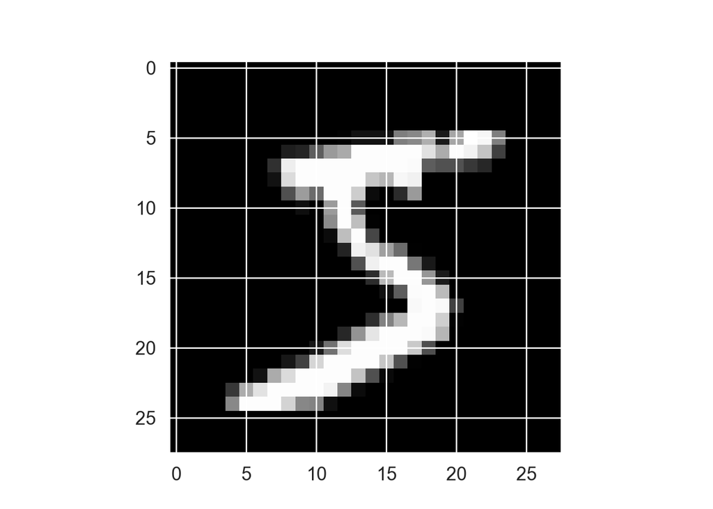

```python
import matplotlib.pyplot as plt

# Feature: digit
plt.figure()
plt.gray()
plt.imshow(x_train[0]);
plt.show()
```

```python
# Label
y_train[0]
```

```
5
```

**R**

```r
mnist <- dataset_mnist()
x_train <- mnist$train$x
y_train <- mnist$train$y
x_test <- mnist$test$x
y_test <- mnist$test$y
```

Training set:

```r
dim(x_train)
```

```
[1] 60000    28    28
```

```r
dim(y_train)
```

```
[1] 60000
```

[figure not shown]

```r
image(
  t(x_train[1, 28:1,]),
  useRaster = TRUE,
  axes = FALSE,
  col = grey(seq(0, 1, length = 256))
  )
```

```r
y_train[1]
```

```
[1] 5
```

Testing set:

```r
dim(x_test)
```

```
[1] 10000    28    28
```

```r
dim(y_test)
```

```
[1] 10000
```

Vectorize $28 \times 28$ images into $784$-vectors and scale entries to [0, 1]:

**Python**

```python
# Reshape
x_train = np.reshape(x_train, [x_train.shape[0], 784])
x_test = np.reshape(x_test, [x_test.shape[0], 784])
# Rescale
x_train = x_train / 255
x_test = x_test / 255
# Train
x_train.shape
```

```
(60000, 784)
```

```python
# Test
x_test.shape
```

```
(10000, 784)
```

**R**

```r
# reshape
x_train <- array_reshape(x_train, c(nrow(x_train), 784))
x_test <- array_reshape(x_test, c(nrow(x_test), 784))
# rescale
x_train <- x_train / 255
x_test <- x_test / 255
dim(x_train)
```

```
[1] 60000   784
```

```r
dim(x_test)
```

```
[1] 10000   784
```

Encode $y$ as binary class matrix:

**Python**

```python
y_train = keras.utils.to_categorical(y_train, 10)
y_test = keras.utils.to_categorical(y_test, 10)
# Train
y_train.shape
```

```
(60000, 10)
```

```python
# Test
y_test.shape
```

```
(10000, 10)
```

```python
# First train instance
y_train[0]
```

```
array([0., 0., 0., 0., 0., 1., 0., 0., 0., 0.], dtype=float32)
```

**R**

```r
y_train <- to_categorical(y_train, 10)
y_test <- to_categorical(y_test, 10)
dim(y_train)
```

```
[1] 60000    10
```

```r
dim(y_test)
```

```
[1] 10000    10
```

```r
head(y_train)
```

```
     [,1] [,2] [,3] [,4] [,5] [,6] [,7] [,8] [,9] [,10]
[1,]    0    0    0    0    0    1    0    0    0     0
[2,]    1    0    0    0    0    0    0    0    0     0
[3,]    0    0    0    0    1    0    0    0    0     0
[4,]    0    1    0    0    0    0    0    0    0     0
[5,]    0    0    0    0    0    0    0    0    0     1
[6,]    0    0    1    0    0    0    0    0    0     0
```

## 2 Define the model

Define a **sequential model** (a linear stack of layers) with 2 fully-connected hidden layers (256 and 128 neurons):

**Python**

```python
model = keras.Sequential(
  [
    keras.Input(shape = (784,)),
    layers.Dense(units = 256, activation = 'relu'),
    layers.Dropout(rate = 0.4),
    layers.Dense(units = 128, activation = 'relu'),
    layers.Dropout(rate = 0.3),
    layers.Dense(units = 10, activation = 'softmax')
]
)

model.summary()
```

```
Model: "sequential"
_________________________________________________________________
 Layer (type)                Output Shape              Param #
=================================================================
 dense (Dense)               (None, 256)               200960

 dropout (Dropout)           (None, 256)               0

 dense_1 (Dense)             (None, 128)               32896

 dropout_1 (Dropout)         (None, 128)               0

 dense_2 (Dense)             (None, 10)                1290

=================================================================
Total params: 235146 (918.54 KB)
Trainable params: 235146 (918.54 KB)
Non-trainable params: 0 (0.00 Byte)
_________________________________________________________________
```

Plot the model:

```python
tf.keras.utils.plot_model(
    model,
    to_file = "model.png",
    show_shapes = True,
    show_dtype = False,
    show_layer_names = True,
    rankdir = "TB",
    expand_nested = False,
    dpi = 96,
    layer_range = None,
    show_layer_activations = False,
)
```

```
You must install pydot (`pip install pydot`) and install graphviz (see instructions at https://graphviz.gitlab.io/download/) for plot_model to work.
```

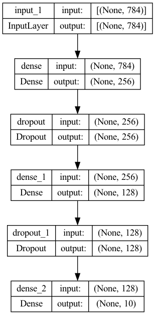

**R**

```r
model <- keras_model_sequential()
model %>%
  layer_dense(units = 256, activation = 'relu', input_shape = c(784)) %>%
  layer_dropout(rate = 0.4) %>%
  layer_dense(units = 128, activation = 'relu') %>%
  layer_dropout(rate = 0.3) %>%
  layer_dense(units = 10, activation = 'softmax')
summary(model)
```

[output not shown]

Compile the model with appropriate loss function, optimizer, and metrics:

**Python**

```python
model.compile(
  loss = "categorical_crossentropy",
  optimizer = "rmsprop",
  metrics = ["accuracy"]
)
```

**R**

```r
model %>% compile(
  loss = 'categorical_crossentropy',
  optimizer = optimizer_rmsprop(),
  metrics = c('accuracy')
)
```

## 3 Training and validation

80%/20% split for the train/validation set.

**Python**

```python
batch_size = 128
epochs = 30

history = model.fit(
  x_train,
  y_train,
  batch_size = batch_size,
  epochs = epochs,
  validation_split = 0.2
)
```

Plot training history:

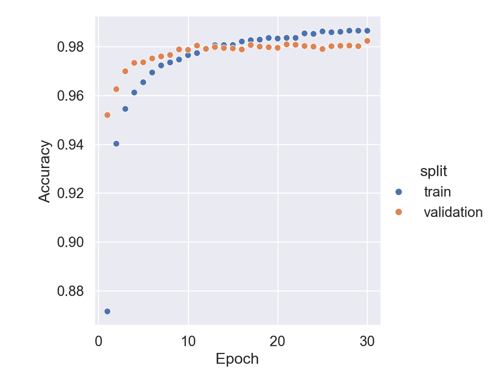

```python
hist = pd.DataFrame(history.history)
hist['epoch'] = np.arange(1, epochs + 1)
hist = hist.melt(
  id_vars = ['epoch'],
  value_vars = ['loss', 'accuracy', 'val_loss', 'val_accuracy'],
  var_name = 'type',
  value_name = 'value'
)
hist['split'] = np.where(['val' in s for s in hist['type']], 'validation', 'train')
hist['metric'] = np.where(['loss' in s for s in hist['type']], 'loss', 'accuracy')

# Accuracy trace plot
plt.figure()
sns.relplot(
  data = hist[hist['metric'] == 'accuracy'],
  kind = 'scatter',
  x = 'epoch',
  y = 'value',
  hue = 'split'
).set(
  xlabel = 'Epoch',
  ylabel = 'Accuracy'
);
plt.show()
```

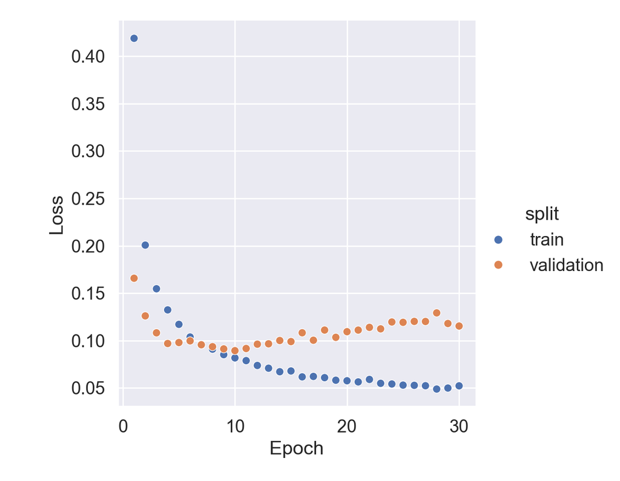

```python
# Loss trace plot
plt.figure()
sns.relplot(
  data = hist[hist['metric'] == 'loss'],
  kind = 'scatter',
  x = 'epoch',
  y = 'value',
  hue = 'split'
).set(
  xlabel = 'Epoch',
  ylabel = 'Loss'
);
plt.show()
```

**R**

```r
system.time({
history <- model %>% fit(
  x_train, y_train,
  epochs = 30, batch_size = 128,
  validation_split = 0.2
)
})
```

```
375/375 - 1s - loss: 0.4363 - accuracy: 0.8676 - val_loss: 0.1707 - val_accuracy: 0.9491 - 972ms/epoch - 3ms/step
375/375 - 1s - loss: 0.2043 - accuracy: 0.9392 - val_loss: 0.1204 - val_accuracy: 0.9648 - 789ms/epoch - 2ms/step
375/375 - 1s - loss: 0.1598 - accuracy: 0.9523 - val_loss: 0.1083 - val_accuracy: 0.9675 - 775ms/epoch - 2ms/step
375/375 - 1s - loss: 0.1325 - accuracy: 0.9600 - val_loss: 0.0969 - val_accuracy: 0.9727 - 774ms/epoch - 2ms/step
375/375 - 1s - loss: 0.1160 - accuracy: 0.9650 - val_loss: 0.0907 - val_accuracy: 0.9750 - 769ms/epoch - 2ms/step
375/375 - 1s - loss: 0.1037 - accuracy: 0.9689 - val_loss: 0.0851 - val_accuracy: 0.9762 - 763ms/epoch - 2ms/step
375/375 - 1s - loss: 0.0953 - accuracy: 0.9708 - val_loss: 0.0877 - val_accuracy: 0.9776 - 767ms/epoch - 2ms/step
375/375 - 1s - loss: 0.0898 - accuracy: 0.9735 - val_loss: 0.0874 - val_accuracy: 0.9758 - 761ms/epoch - 2ms/step
375/375 - 1s - loss: 0.0812 - accuracy: 0.9749 - val_loss: 0.0851 - val_accuracy: 0.9772 - 766ms/epoch - 2ms/step
375/375 - 1s - loss: 0.0759 - accuracy: 0.9780 - val_loss: 0.0835 - val_accuracy: 0.9779 - 773ms/epoch - 2ms/step
375/375 - 1s - loss: 0.0734 - accuracy: 0.9784 - val_loss: 0.0896 - val_accuracy: 0.9778 - 762ms/epoch - 2ms/step
375/375 - 1s - loss: 0.0679 - accuracy: 0.9791 - val_loss: 0.0873 - val_accuracy: 0.9793 - 771ms/epoch - 2ms/step
375/375 - 1s - loss: 0.0677 - accuracy: 0.9794 - val_loss: 0.0887 - val_accuracy: 0.9792 - 770ms/epoch - 2ms/step
375/375 - 1s - loss: 0.0629 - accuracy: 0.9810 - val_loss: 0.0895 - val_accuracy: 0.9793 - 757ms/epoch - 2ms/step
375/375 - 1s - loss: 0.0598 - accuracy: 0.9819 - val_loss: 0.0974 - val_accuracy: 0.9776 - 757ms/epoch - 2ms/step
375/375 - 1s - loss: 0.0577 - accuracy: 0.9828 - val_loss: 0.0920 - val_accuracy: 0.9792 - 766ms/epoch - 2ms/step
375/375 - 1s - loss: 0.0581 - accuracy: 0.9824 - val_loss: 0.0946 - val_accuracy: 0.9804 - 772ms/epoch - 2ms/step
375/375 - 1s - loss: 0.0539 - accuracy: 0.9843 - val_loss: 0.0952 - val_accuracy: 0.9797 - 776ms/epoch - 2ms/step
375/375 - 1s - loss: 0.0517 - accuracy: 0.9843 - val_loss: 0.0935 - val_accuracy: 0.9809 - 767ms/epoch - 2ms/step
375/375 - 1s - loss: 0.0516 - accuracy: 0.9847 - val_loss: 0.0975 - val_accuracy: 0.9795 - 770ms/epoch - 2ms/step
375/375 - 1s - loss: 0.0492 - accuracy: 0.9846 - val_loss: 0.0953 - val_accuracy: 0.9793 - 754ms/epoch - 2ms/step
375/375 - 1s - loss: 0.0481 - accuracy: 0.9857 - val_loss: 0.0946 - val_accuracy: 0.9813 - 757ms/epoch - 2ms/step
375/375 - 1s - loss: 0.0448 - accuracy: 0.9860 - val_loss: 0.0978 - val_accuracy: 0.9803 - 761ms/epoch - 2ms/step
375/375 - 1s - loss: 0.0492 - accuracy: 0.9856 - val_loss: 0.0945 - val_accuracy: 0.9812 - 763ms/epoch - 2ms/step
375/375 - 1s - loss: 0.0446 - accuracy: 0.9870 - val_loss: 0.0964 - val_accuracy: 0.9812 - 769ms/epoch - 2ms/step
375/375 - 1s - loss: 0.0451 - accuracy: 0.9866 - val_loss: 0.0943 - val_accuracy: 0.9804 - 765ms/epoch - 2ms/step
375/375 - 1s - loss: 0.0437 - accuracy: 0.9867 - val_loss: 0.0999 - val_accuracy: 0.9817 - 754ms/epoch - 2ms/step
375/375 - 1s - loss: 0.0418 - accuracy: 0.9878 - val_loss: 0.1008 - val_accuracy: 0.9806 - 773ms/epoch - 2ms/step
375/375 - 1s - loss: 0.0410 - accuracy: 0.9876 - val_loss: 0.1037 - val_accuracy: 0.9811 - 758ms/epoch - 2ms/step
375/375 - 1s - loss: 0.0405 - accuracy: 0.9881 - val_loss: 0.0988 - val_accuracy: 0.9819 - 754ms/epoch - 2ms/step
```

```
   user  system elapsed
 51.622  23.955  23.306
```

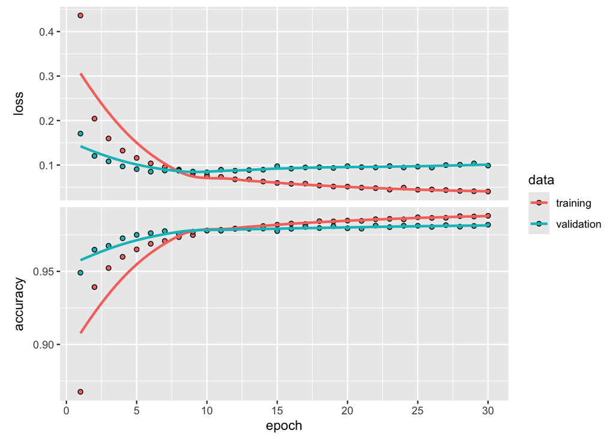

```r
plot(history)
```

## 4 Testing

Evaluate model performance on the test data:

**Python**

```python
score = model.evaluate(x_test, y_test, verbose = 0)
print("Test loss:", score[0])
```

```
Test loss: 0.10371148586273193
```

```python
print("Test accuracy:", score[1])
```

```
Test accuracy: 0.98089998960495
```

**R**

```r
model %>% evaluate(x_test, y_test)
```

```
313/313 - 0s - loss: 0.0912 - accuracy: 0.9826 - 129ms/epoch - 413us/step
```

```
      loss   accuracy
0.09118301 0.98259997
```

Generate predictions on new data:

```r
model %>% predict(x_test) %>% k_argmax()
```

```
313/313 - 0s - 147ms/epoch - 470us/step
```

```
tf.Tensor([7 2 1 ... 4 5 6], shape=(10000), dtype=int64)
```

## 5 Exercise

Suppose we want to fit a multinomial-logit model and use it as a baseline method to neural networks. How to do that? Of course we can use `mlogit` or other packages. Instead we can fit the same model using keras, since multinomial-logit is just an MLP with (1) one input layer with linear activation and (2) one output layer with softmax link function.

**Python**

**R**

```r
# set up model
library(keras)
mlogit <- keras_model_sequential()
mlogit %>%
#  layer_dense(units = 256, activation = 'linear', input_shape = c(784)) %>%
#  layer_dropout(rate = 0.4) %>%
  layer_dense(units = 10, activation = 'softmax', input_shape = c(784))
summary(mlogit)
```

```
Model: "sequential_2"
________________________________________________________________________________
 Layer (type)                       Output Shape                    Param #
================================================================================
 dense_6 (Dense)                    (None, 10)                      7850
================================================================================
Total params: 7850 (30.66 KB)
Trainable params: 7850 (30.66 KB)
Non-trainable params: 0 (0.00 Byte)
________________________________________________________________________________
```

```r
# compile model
mlogit %>% compile(
  loss = 'categorical_crossentropy',
  optimizer = optimizer_rmsprop(),
  metrics = c('accuracy')
)
mlogit
```

```
Model: "sequential_2"
________________________________________________________________________________
 Layer (type)                       Output Shape                    Param #
================================================================================
 dense_6 (Dense)                    (None, 10)                      7850
================================================================================
Total params: 7850 (30.66 KB)
Trainable params: 7850 (30.66 KB)
Non-trainable params: 0 (0.00 Byte)
________________________________________________________________________________
```

```r
# fit model
mlogit_history <- mlogit %>%
  fit(
    x_train,
    y_train,
    epochs = 20,
    batch_size = 128,
    validation_split = 0.2
  )
```

```
375/375 - 0s - loss: 0.6783 - accuracy: 0.8322 - val_loss: 0.3608 - val_accuracy: 0.9038 - 351ms/epoch - 936us/step
375/375 - 0s - loss: 0.3545 - accuracy: 0.9016 - val_loss: 0.3085 - val_accuracy: 0.9152 - 207ms/epoch - 551us/step
375/375 - 0s - loss: 0.3189 - accuracy: 0.9116 - val_loss: 0.2922 - val_accuracy: 0.9186 - 207ms/epoch - 551us/step
375/375 - 0s - loss: 0.3025 - accuracy: 0.9157 - val_loss: 0.2831 - val_accuracy: 0.9207 - 207ms/epoch - 552us/step
375/375 - 0s - loss: 0.2929 - accuracy: 0.9181 - val_loss: 0.2777 - val_accuracy: 0.9229 - 216ms/epoch - 576us/step
375/375 - 0s - loss: 0.2859 - accuracy: 0.9203 - val_loss: 0.2743 - val_accuracy: 0.9246 - 205ms/epoch - 548us/step
375/375 - 0s - loss: 0.2808 - accuracy: 0.9219 - val_loss: 0.2718 - val_accuracy: 0.9249 - 207ms/epoch - 551us/step
375/375 - 0s - loss: 0.2773 - accuracy: 0.9228 - val_loss: 0.2687 - val_accuracy: 0.9277 - 212ms/epoch - 566us/step
375/375 - 0s - loss: 0.2739 - accuracy: 0.9240 - val_loss: 0.2677 - val_accuracy: 0.9273 - 205ms/epoch - 548us/step
375/375 - 0s - loss: 0.2713 - accuracy: 0.9248 - val_loss: 0.2672 - val_accuracy: 0.9283 - 212ms/epoch - 566us/step
375/375 - 0s - loss: 0.2689 - accuracy: 0.9256 - val_loss: 0.2657 - val_accuracy: 0.9273 - 219ms/epoch - 583us/step
375/375 - 0s - loss: 0.2670 - accuracy: 0.9259 - val_loss: 0.2655 - val_accuracy: 0.9279 - 205ms/epoch - 547us/step
375/375 - 0s - loss: 0.2650 - accuracy: 0.9268 - val_loss: 0.2645 - val_accuracy: 0.9288 - 206ms/epoch - 550us/step
375/375 - 0s - loss: 0.2636 - accuracy: 0.9268 - val_loss: 0.2637 - val_accuracy: 0.9284 - 211ms/epoch - 562us/step
375/375 - 0s - loss: 0.2618 - accuracy: 0.9273 - val_loss: 0.2635 - val_accuracy: 0.9305 - 207ms/epoch - 551us/step
375/375 - 0s - loss: 0.2604 - accuracy: 0.9283 - val_loss: 0.2631 - val_accuracy: 0.9291 - 206ms/epoch - 549us/step
375/375 - 0s - loss: 0.2595 - accuracy: 0.9289 - val_loss: 0.2626 - val_accuracy: 0.9299 - 212ms/epoch - 565us/step
375/375 - 0s - loss: 0.2583 - accuracy: 0.9289 - val_loss: 0.2632 - val_accuracy: 0.9295 - 210ms/epoch - 560us/step
375/375 - 0s - loss: 0.2574 - accuracy: 0.9294 - val_loss: 0.2641 - val_accuracy: 0.9290 - 210ms/epoch - 559us/step
375/375 - 0s - loss: 0.2562 - accuracy: 0.9301 - val_loss: 0.2648 - val_accuracy: 0.9292 - 206ms/epoch - 548us/step
```

```r
# Evaluate model performance on the test data:
mlogit %>% evaluate(x_test, y_test)
```

```
313/313 - 0s - loss: 0.2678 - accuracy: 0.9267 - 88ms/epoch - 280us/step
```

```
     loss  accuracy
0.2677798 0.9267000
```

Generate predictions on new data:

```r
mlogit %>% predict(x_test) %>% k_argmax()
```

```
313/313 - 0s - 81ms/epoch - 259us/step
```

```
tf.Tensor([7 2 1 ... 4 5 6], shape=(10000), dtype=int64)
```

Experiment: Change the `linear` activation to `relu` in the multinomial-logit model and see the change in classification accuracy.